# Лабораторная работа № 11

Управление загрузкой системы

Павличенко Родион Андреевич

1132246838@pfur.ru

Российский университет дружбы народов

2025-06-09

# Информация

## Докладчик

- Павличенко Родион Андреевич
- Cтудент
- Группа НПИбд-02-24
- Российский университет дружбы народов им. П. Лумумбы
- 1132246838@pfur.ru

# Выполнение лабораторной работы

## Запустили терминал и получили полномочия администратора. В файле /etc/default/grub установили параметр отображения меню загрузки в течение 10 секунд.

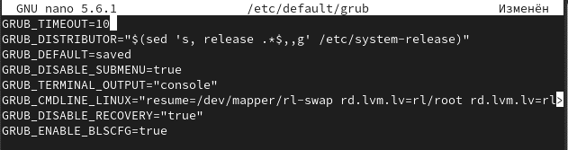

## Записали изменения в GRUB2, введя в командной строке grub2-mkconfig > /boot/grub2/grub.cfg.

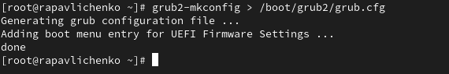

## Перезагрузили систему и убедились, что при загрузке мы видим прокрутку загрузочных сообщений..

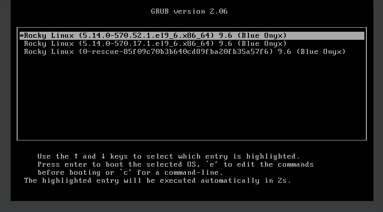

## Перегрузили систему. Как только появится меню GRUB, выбрали строку с текущей версией ядра в меню и нажали e для редактирования. Прокрутили вниз до строки, начинающейся с linux ($root)/vmlinuz- и в конце этой строки ввели systemd.unit=rescue.target и удалили опции rhgb и quit. Нажали Ctrl + x для продолжения процесса загрузки. Ввели пароль пользователя root.

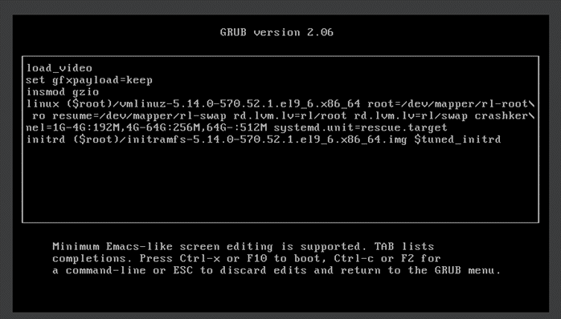

## Посмотрели список всех файлов модулей, которые загружены в настоящее время командой systemctl list-units

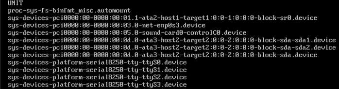

## Посмотрели задействованные переменные среды оболочки командой systemctl show-environment. Перезагрузили систему.

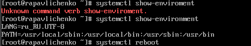

## Как только отобразится меню GRUB, ещё раз нажали e на строке с текущей версией ядра, чтобы войти в режим редактора. В конце строки, загружающей ядро, ввели systemd.unit=emergency.target и удалили опции rhgb и quit. Нажали Ctrl + x для продолжения процесса загрузки. Ввели пароль пользователя root.

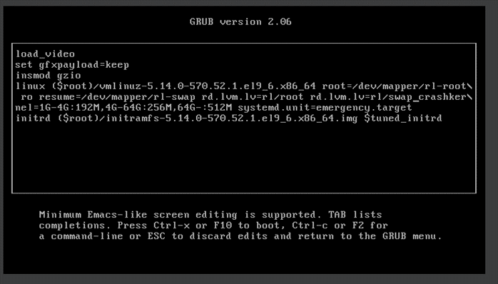

## После успешного входа в систему посмотрели список всех загруженных файлов модулей командой systemctl list-units. Обратили внимание, что количество загружаемых файлов модулей уменьшилось до минимума

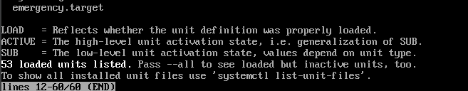

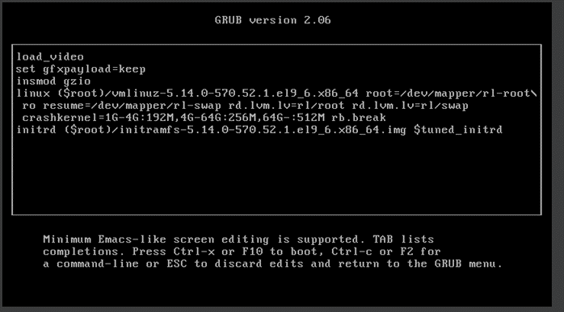

## Чтобы получить доступ к системному образу для чтения и записи, набрали mount -o remount,rw /sysroot. Сделали содержимое каталога /sysimage новым корневым каталогом, набрав chroot /sysroot. Ввели команду задания пароля: passwd и установили новый пароль для пользователя root

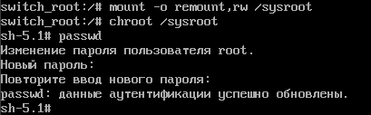

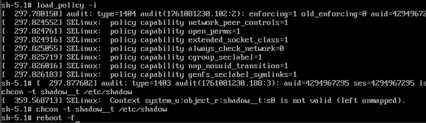